# Suavizacao e Decomposicao

#### nottem

- O que é: temperaturas médias mensais em Nottingham (Inglaterra).
- Período aproximado: 1920–1939.
- Frequência: 12 (mensal).
- O que observar: sazonalidade climática clara (ciclos anuais inverno–verão) e nível médio relativamente estável (pouca tendência de longo prazo no intervalo).

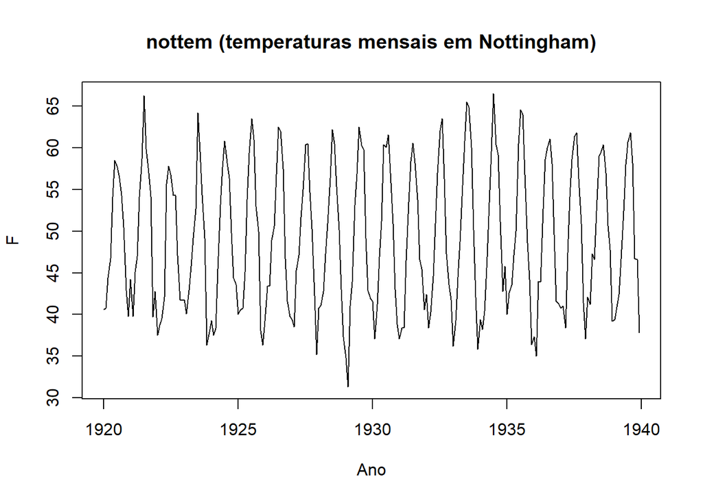

```r
plot(nottem, main = "nottem (temperaturas mensais em Nottingham)", ylab = "F", xlab = "Ano")
```

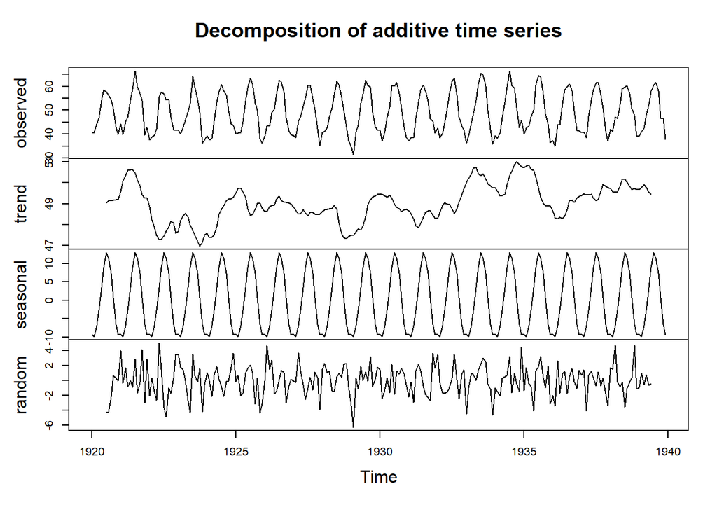

```r
plot(decompose(nottem,type = "a"))
```

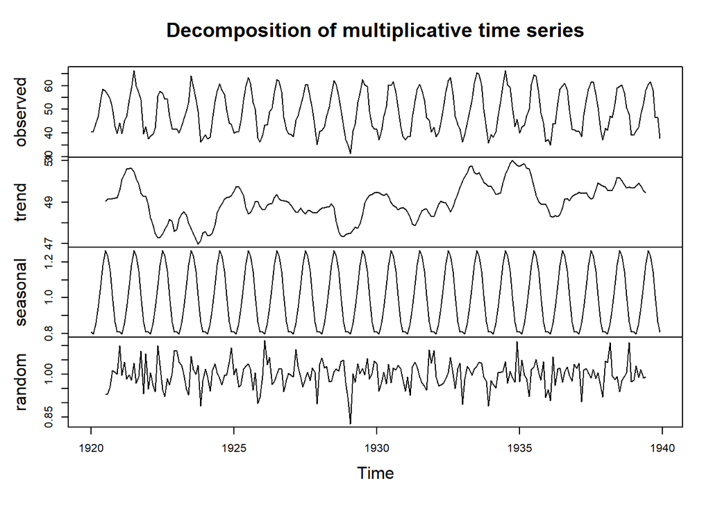

```r
plot(decompose(nottem,type = "m"))
```

#### presidents

- O que é: índices trimestrais de aprovação de presidentes dos EUA.
- Período aproximado: 1945–1974.
- Frequência: 4 (trimestral).
- O que observar: mudanças de nível associadas a ciclos políticos/econômicos; sazonalidade não é a característica principal aqui.

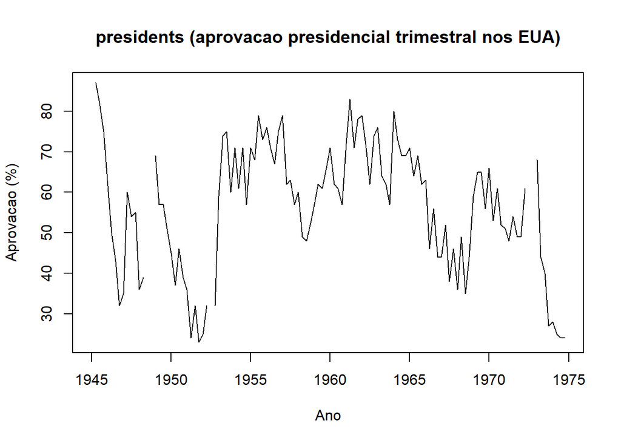

```r
plot(presidents, main = "presidents (aprovacao presidencial trimestral nos EUA)", ylab = "Aprovacao (%)", xlab = "Ano")
```

### Decomposicao STL

- STL é uma abreviação de *Seasonal and Treding using Loess*;
- Esta é uma forma mais robusta de decomposição;
- A componente sazonal é dinâmica, ou seja, pode mudar ao longo do tempo;
- Apenas para decomposição aditiva:

  $$X_t = T_t + S_t + E_t$$
- A decomposição multiplicativa pode ser obtida aplicando STL no log da série, i.e.,

  $$\log X_t = \log T_t + \log S_t + \log E_t$$

  então

  $$X_t = T_t \times S_t \times E_t$$

### Decomposicao STL (Manual)

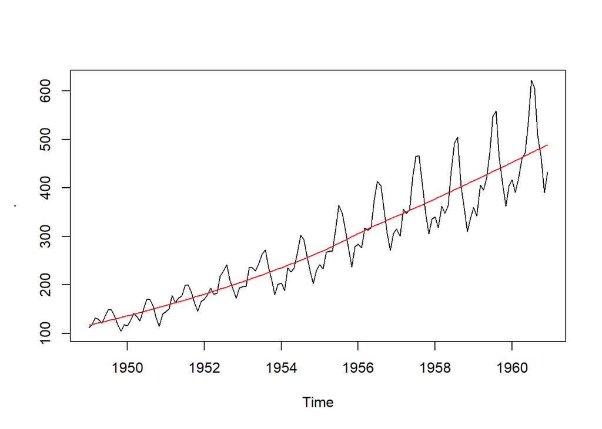

```r
AirPassengers %>% plot

X <- AirPassengers
tempo <- time(AirPassengers)


##
# 1) Ajustar a tendencia via Loess
T <- loess(X ~ tempo)$fitted

T <- ts(T, start=start(X), frequency=frequency(X))

lines(T, col='red')
```

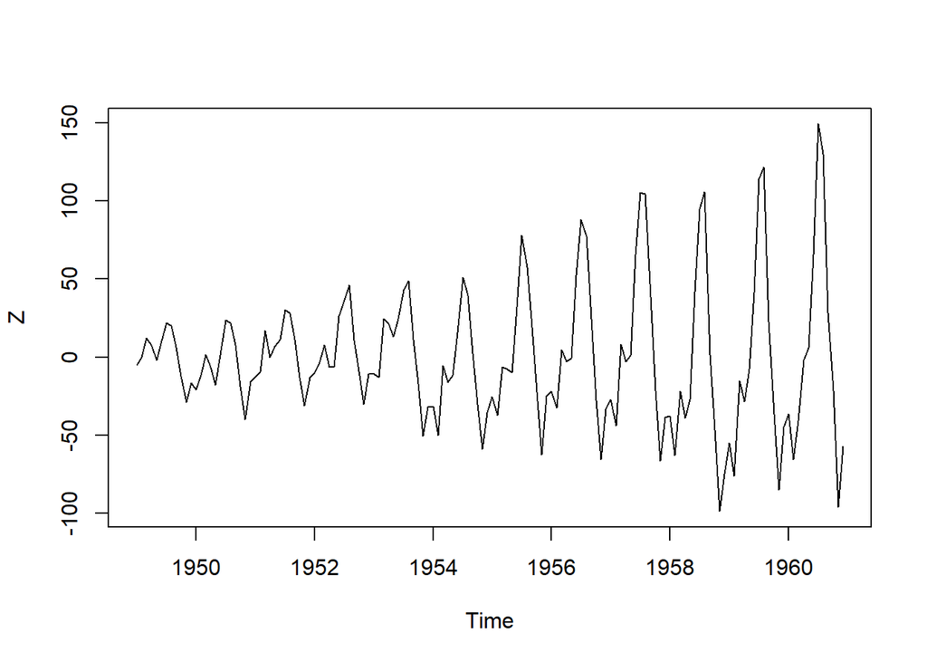

```r
# 2) Obter a serie com tend?ncia ajustada
Z <- X - T

plot(Z)
```

```r
# 3) Ajustar o termo de sazonalidade
require(zoo)
```

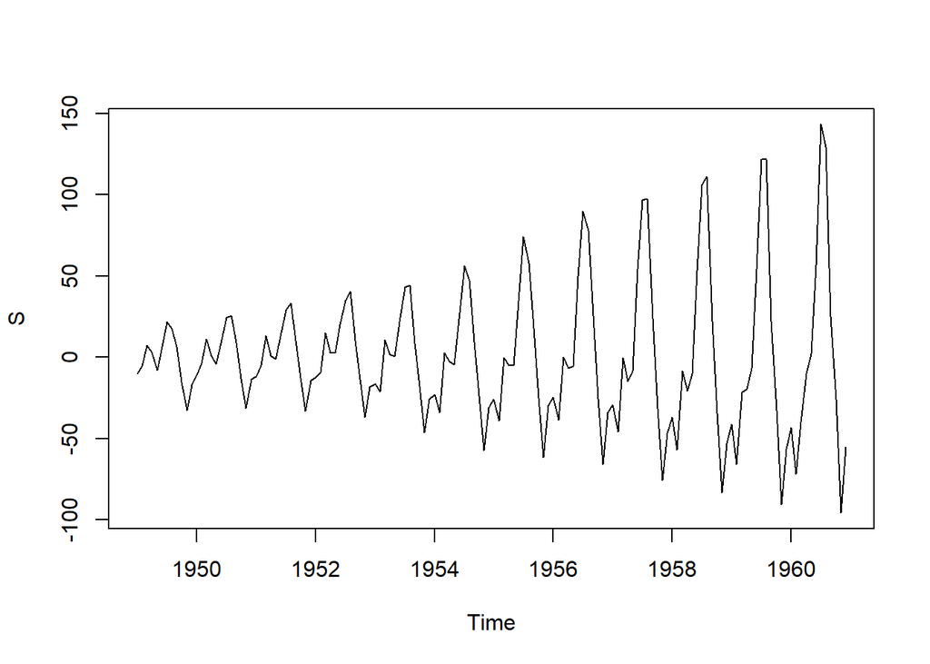

```r
require(forecast)

S <- rep(NA, length(Z))

  # ajusta uma regressao de loess para o mes de janeiro,
  # outra para fevereiro e assim por diante.
  ### o parametro span é equivalente a s.window/(numero de ciclos completos)
for(i in 1:12){
  idx <- which( cycle(Z)==i )
  Z.m <- Z[idx]
  S.m <- loess( Z.m ~ index(Z.m), span = 8/12 )$fitted
  S[idx] <- S.m
}

S <- ts(S, start=start(X), frequency = frequency(X))

plot(S)
```

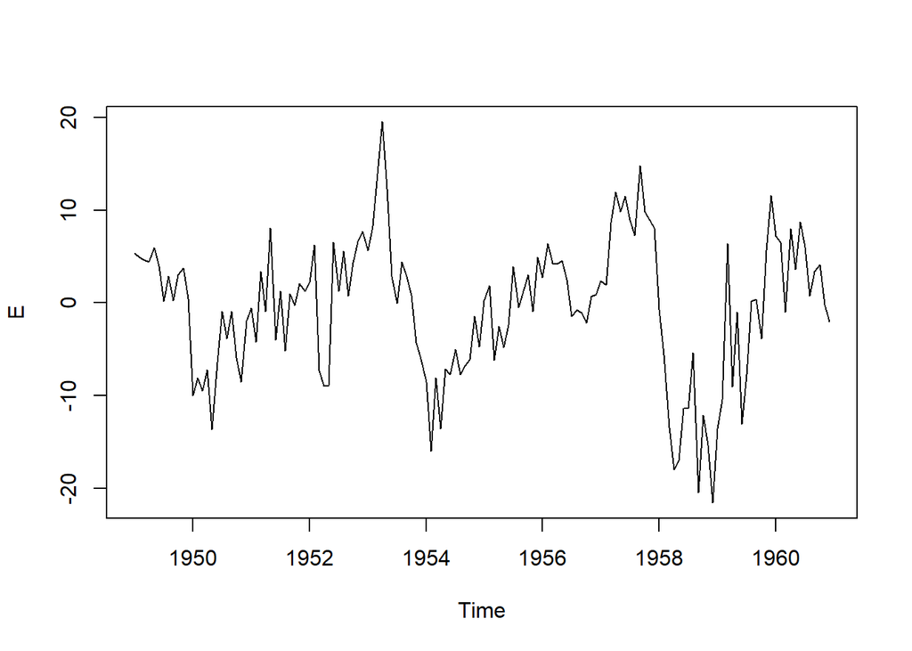

```r
# 4) Calcular os residuos
E <- X-T-S

plot(E)
```

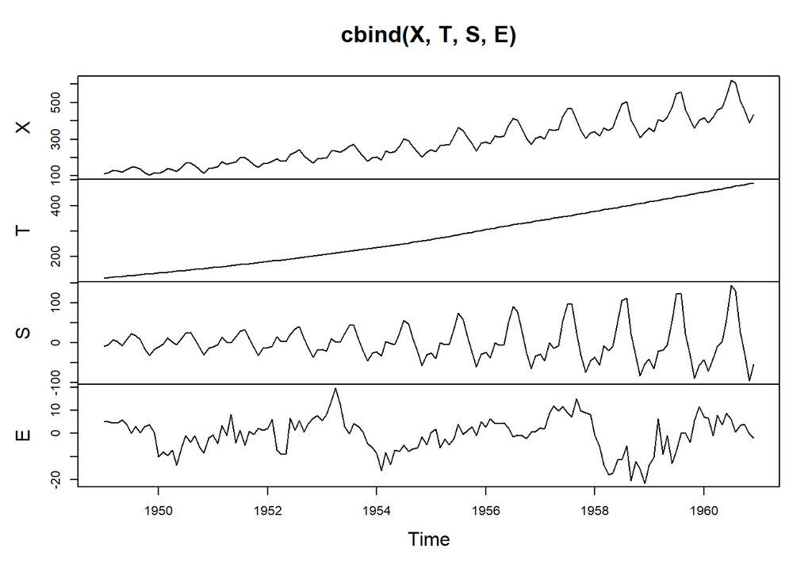

```r
plot(cbind(X,T,S,E))
```